# Sampling the Imaginary

Florian Sckade

```r
library(rethinking)
library(tidyverse)
```

Disclaimer: These are paraphrased or even direct quotes from the book.

Bayesian inference is distinguished by a broad view of probability, not by the use of Bayes’ theorem. A central part explained here is the working with samples from the posterior distribution, to make inference in the style of questions for the defined model easier. This is opposed to the classic integral calculus you utilize when usually working with distribution functions. With this method, instead of using these mathematical formulas for integration, you can just use standard data summary methods-

My favorite quote from the first section of the chapter:

> “No one has ever seen a probability”

#### **Rethinking:** Hypothesis-Testing

Scientific inference process: (1) An hypothesis is true or false; (2) we calculate a statistical measure to determine if the hypothesis is likely to be true/false; (3) one *should* use Bayes theorem to deduce the impact of our measurement on the original hypothesis. The example: suppose the probability of a positive finding when the hypothesis is true (*power*), is Pr(sig$|$true)=0.95, and that the probability of a positive finding when the hypothesis is false is Pr(sig$|$false)=0.05 (*false positive rate*, like the conventional 5% in significance testing). Additionally, suppose that 1 in every 100 hypothesis is true, Pr(true)=0.01. Thus, in this scenario, we can calculate Pr(true$|$pos)=0.16, meaning a positive finding corresponds to a probability of 16% that the hypothesis is true. An shrinking of the false-positve rate to 1% does not solve this problem, merely improving the posterior probability to a 0.5. Pr(true) is the most essential rate in this setting, for which thinking is required, not testing.

## Sampling to summarize

Once a posterior distribution is estimated, samples can be drawn from it. In the first place, this only recreates the density function we already calculated. However, these samples can also then be used to *describe* and *understand* the posterior, which is very important.

Common questions for summaries of posterior samples:

- How much posterior probability lies below some parameter value?
- How much posterior probability lies between two parameter values?
- Which parameter value marks the lower 5% of the posterior probability?
- Which range of parameter values contains 90% of the posterior probability?
- Which parameter value has highest posterior probability?

These questions can be divided into:

1. questions about intervals of defined boundaries,
2. questions about intervals of defined probability mass
3. questions about point estimates.

Essentially, there are different types of intervals you can utilize to analyze the posterior. For (1), this means setting an interval based on specific parameter values and analyzing, how much probability mass lies between these boundaries. In terms of defines mass (2), one can build *compatibility intervals*. These posterior intervals report two parameter values that contain between them a specified amount of posterior probability. Point estimates (3) depend on more information, as to what kind of summary statistic should actually be utilized. The bayesian parameter estimate is precisely the posterior distribution, and as such, the decision on a point estimate to summarize this distribution is not trivial. When deciding between different point estimates (mode, mean, median), one can use *loss functions*. Examples are *absolute loss*(leads to median) and *quadratic loss* (leads to posterior mean).

### Compatibility intervals:

#### PI

For a given percentage number x, the percentile intervals (PI) find the middle x% probability. Example: 80% posterior probability percentile interval would give the 10% and 90% quantiles as l lower and upper bounds to that interval.

#### HDPI

The Highest Posterior Density Interval gives the bounds for the narrowest interval containing the given probability mass x%. It always contains the parameter with the highest posterior probability.

## Sampling to simulate prediction

Samples can be used to generate implied observations, which is useful because of:

1. *Model Design*: Sample the prior to understand its implications.
2. *Model checking*: Investigate model behavior after updating and check if it worked correctly.
3. *Software validation*: Check if model fitting software works as expected.
4. *Research design*: Simulate observations from the hypothesis, to evaluate research design. (akin to power analysis)
5. *Forecasting*: Samples can be used as predictions, but also as model criticism.

# Exercises

```r
p_grid <- seq(from = 0, to = 1, length.out = 1000)
prior <- rep(1, 1000)
likelihood <- dbinom(6, size = 9, prob = p_grid)
posterior <- likelihood * prior
posterior <- posterior / sum(posterior)

set.seed(100)
samples <- sample(p_grid, prob = posterior, size = 1e4, replace = TRUE)
```

#### 3E1. How much posterior probability lies below p = 0.2?

```r
# Either this way
sum(samples < 0.2) / 1e4
```

```
## [1] 4e-04
```

```r
# or more directly:
mean(samples < 0.2)
```

```
## [1] 4e-04
```

#### 3E2. How much posterior probability lies above p = 0.8?

```r
mean(samples > 0.8)
```

```
## [1] 0.1116
```

#### 3E3. How much posterior probability lies between p = 0.2 and p = 0.8?

```r
mean(samples > 0.2 & samples < 0.8)
```

```
## [1] 0.888
```

#### 3E4. 20% of the posterior probability lies below which value of p?

```r
quantile(samples, 0.2)
```

```
##       20%
## 0.5185185
```

#### 3E5. 20% of the posterior probability lies above which value of p?

```r
quantile(samples, 0.8)
```

```
##       80%
## 0.7557558
```

#### 3E6. Which values of p contain the narrowest interval equal to 66% of the posterior probability?

```r
# Highest posterior density interval
rethinking::HPDI(samples, prob = 0.66)
```

```
##     |0.66     0.66|
## 0.5085085 0.7737738
```

#### 3E7. Which values of p contain 66% of the posterior probability, assuming equal posterior probability both below and above the interval?

```r
# Percentile interval
rethinking::PI(samples, prob = 0.66)
```

```
##       17%       83%
## 0.5025025 0.7697698
```

#### 3M1.

Suppose the globe tossing data had turned out to be 8 water in 15 tosses. Construct the posterior distribution, using grid approximation. Use the same flat prior as before.

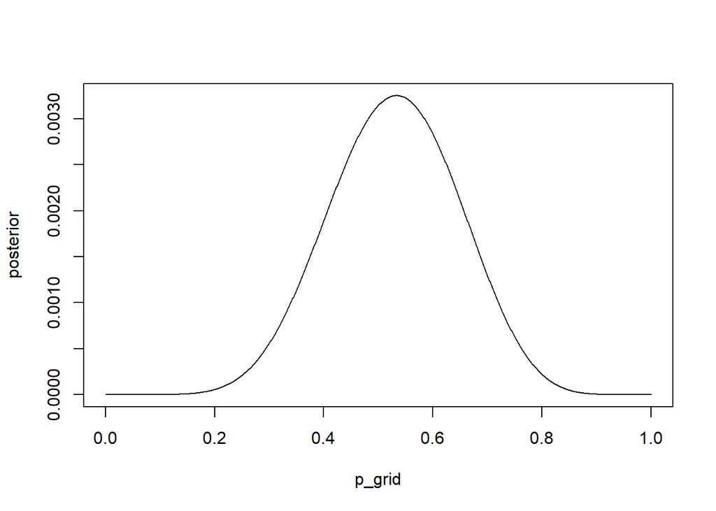

```r
p_grid <- seq(from = 0, to = 1, length.out = 1000)
prior <- rep(1, 1000)
likelihood <- dbinom(8, size = 15, prob = p_grid)
posterior <- likelihood * prior
posterior <- posterior / sum(posterior)
plot(x = p_grid, y = posterior, type = "l")
```

#### 3M2 Draw 10,000 samples from the grid approximation from above. Then use the samples to calculate the 90 % HDPI for p.

```r
samples <- sample(p_grid, prob = posterior, size = 1e4, replace=TRUE)
rethinking::HPDI(samples, prob = 0.9)
```

```
##      |0.9      0.9|
## 0.3293293 0.7167167
```

#### 3M3

Construct a posterior predictive check for this model and data. This means simulate the distribution of samples, averaging over the posterior uncertanity in p. What is the probability of observing 8 water in 15 tosses?

```r
w <- rbinom(1e4, size = 15, prob = samples)
mean(w == 8)
```

```
## [1] 0.1444
```

#### 3M4

Using the posterior distribution constructed from the new (8/15) data, now calculate the probability of observing 6 water in 9 tosses.

```r
w <- rbinom(1e4, size = 9, prob = samples)
mean(w == 6)
```

```
## [1] 0.1751
```

#### 3M5

Start ver at *3M1*, but now use a prior that is zero below p = 0.5 and a constant above p = 0.5. This corresponds to prior information that a majority of the Earth’s surface is water. Repeat each problem above and compare the inferences (using both priors) to the true value p = 0.7.

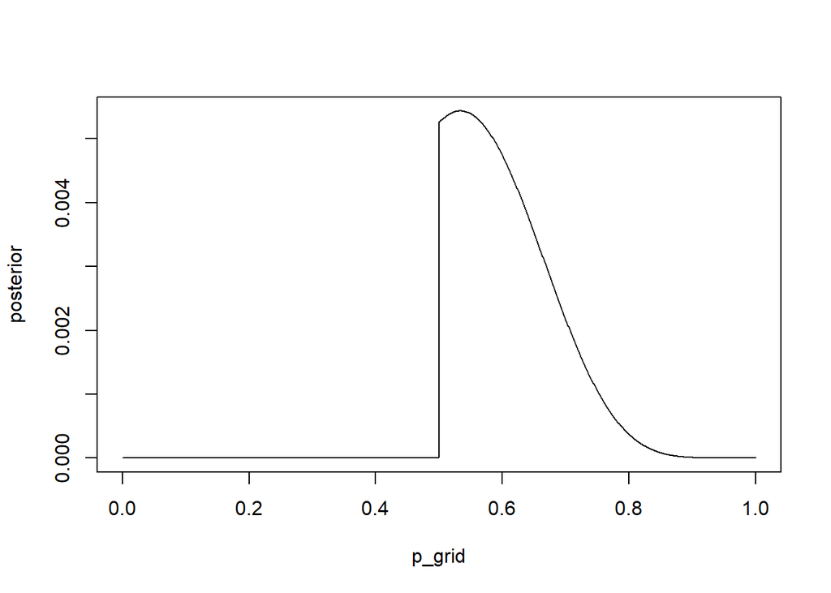

```r
p_grid <- seq(from = 0, to = 1, length.out = 1000)
# Simple if_else solution, others are possible too.
prior <- dplyr::if_else(p_grid > 0.5, 1, 0)

likelihood <- dbinom(8, size = 15, prob = p_grid)
posterior <- likelihood * prior
posterior <- posterior / sum(posterior)
plot(x = p_grid, y = posterior, type = "l")
```

```r
# 3M2 - 2
samples <- sample(p_grid, prob = posterior, size = 1e4, replace=TRUE)
rethinking::HPDI(samples, prob = 0.9)
```

```
##      |0.9      0.9|
## 0.5005005 0.7117117
```

```r
# 3M3 - 2
w <- rbinom(1e4, size = 15, prob = samples)
mean(w == 8)
```

```
## [1] 0.1589
```

```r
# 3M4 - 2
w <- rbinom(1e4, size = 9, prob = samples)
mean(w == 6)
```

```
## [1] 0.2415
```

We can see that the interval (HDPI) is narrower now.

#### 3M6

Suppose you want to estimate the Earth’s proportion of water very precisely. Specifically, you want the 99% percentile interval of the posterior distribution of p to be only 0.05 wide. This means the distance between the upper and lower bound of the interval should be 0.05. How many times will you have to toss the globe to do this?

```r
find_interval <- function(N, p = 0.7) {
  p_grid <- seq(from = 0, to = 1, length.out = 1000)
  prior <- dplyr::if_else(p_grid > 0.5, 1, 0)

  likelihood <- dbinom(round(N*p), size = N, prob = p_grid)
  posterior <- likelihood * prior
  posterior <- posterior / sum(posterior)

  samples <- sample(p_grid, prob=posterior, size=1e4, replace=TRUE )
  pi <- PI(samples, prob=0.99)
  return(diff(pi)[[1]])
}
```

```r
N <- 100
found <- FALSE
while(found == FALSE) {
  value <- find_interval(N)
  if(value <= 0.05) {
    value <- round(value, 4)
    print(paste0("PI with width p = ", value," found for N = ", N))
    found <- TRUE
  } else {
    N <- N + 100
  }
}
```

```
## [1] "PI with width p = 0.0491 found for N = 2300"
```

#### Hard Data

```r
data(homeworkch3)
head(birth1)
```

```
## [1] 1 0 0 0 1 1
```

```r
head(birth2)
```

```
## [1] 0 1 0 1 0 1
```

#### 3H1

Using grid approximation, compute the posterior distribution for the probability of a birth being a boy. Assume a uniform prior probability. Which parameter value maximizes the posterior probability?

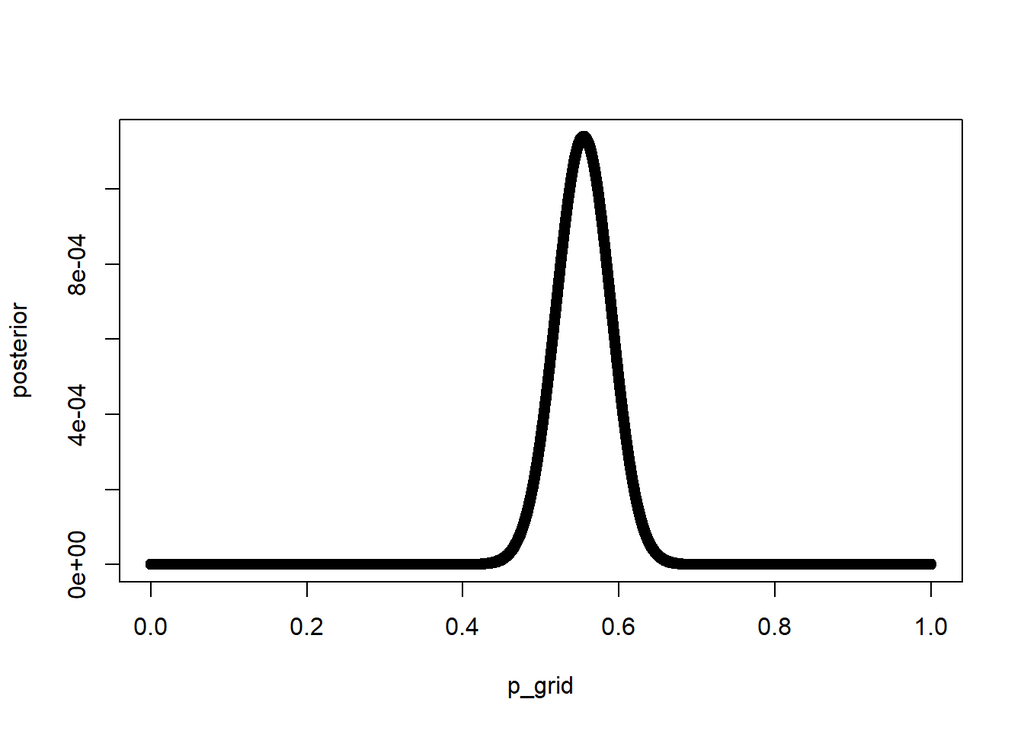

```r
males <- sum(birth1) + sum(birth2)
N <- length(birth1) + length(birth2)

# create grid of probabilities
p_grid <- seq(from=0, to=1, length.out = 10000)
# create uniform prior
prior <- rep(1, 10000)
# calculate likelihood over p_grid
likelihood <- dbinom(males, size=N, prob = p_grid)
posterior <- likelihood * prior
posterior <- posterior / sum(posterior)
plot(x = p_grid, y = posterior)
```

#### 3H2

Using the `sample` function, draw 10,000 random parameter values from the posterior distribution you calculated above. Use these sample to estimate the 50%, 89%, and 97% highest posterior density intervals.

```r
samples <- sample(p_grid, 1e4, replace = TRUE, prob = posterior)

# intervals:
HPDI(samples, c(.5, .89, .97))
```

```
##     |0.97     |0.89      |0.5      0.5|     0.89|     0.97|
## 0.4792479 0.4974497 0.5307531 0.5780578 0.6079608 0.6269627
```

#### 3H3

Use rbinom to simulate 10,000 replicates of 200 births. You should end up with 10,000 numbers, each one a count of boys out of 200 births. Compare the distribution of predicted numbers of boys to the actual count in the data (111 boys out of 200 births). There are many good ways to visualize the simulations, but the dens command (part of the rethinking package) is probably the easiest way in this case. Does it look like the model fits the data well? That is, does the distribution of predictions include the actual observation as a central, likely outcome?

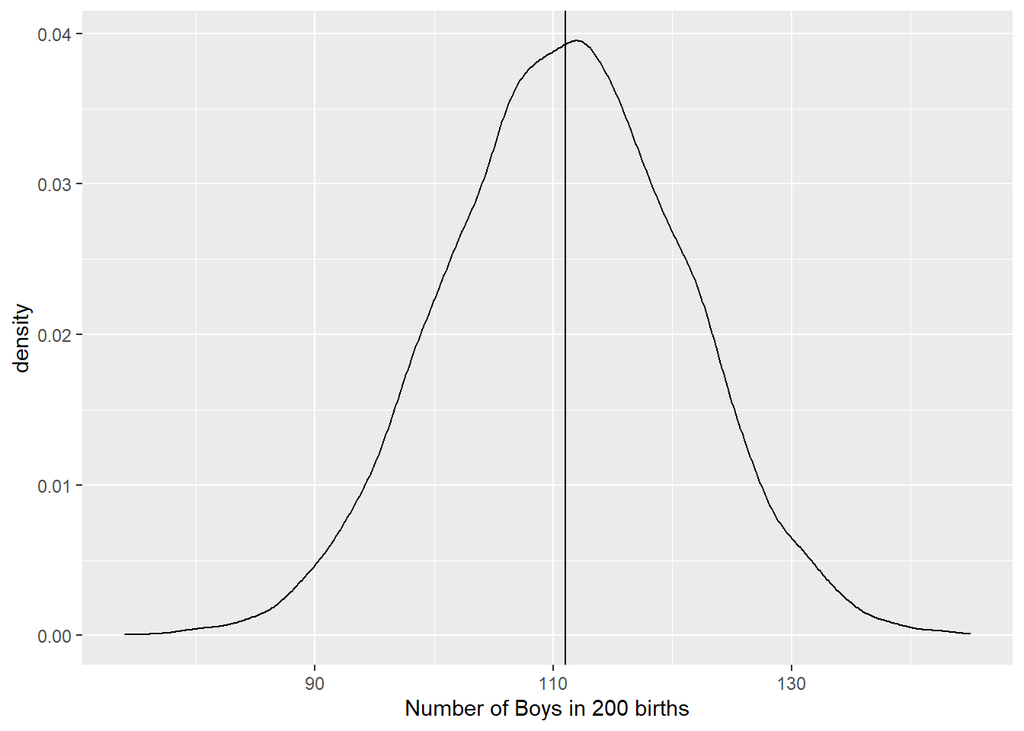

```r
sampled_births <- rbinom(1e4, size = 200, prob = samples)

tibble(male_births = sampled_births) %>%
  ggplot(aes(x = male_births)) +
  geom_density() + geom_vline(xintercept = males) +
  labs(x = "Number of Boys in 200 births")
```

Yeah, the actual number of male births in our sample of 200 is pretty much in the middle of this distribution.

#### 3H4

Now compare 10,000 counts of boys from 100 simulated first borns only to the number of boys in the first births, birth1. How does the model look in this light?

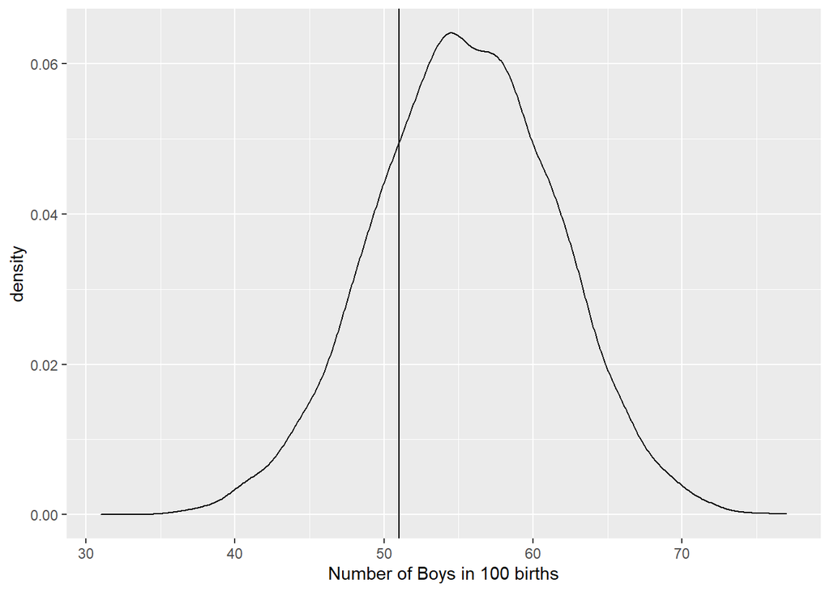

```r
sampled_births <- rbinom(1e4, size = 100, prob = samples)

tibble(male_births = sampled_births) %>%
  ggplot(aes(x = male_births)) +
  geom_density() + geom_vline(xintercept = sum(birth1)) +
  labs(x = "Number of Boys in 100 births")
```

Looks less good, still okay.

#### 3H5

The model assumes that sex of first and second births are independent. To check this assumption, focus now on second births that followed female first borns. Compare 10,000 simulated counts of boys to only those second births that followed girls. Compare the counts of boys in your simulations to the actual observed count of boys following girls. How does the model look in this light? Any guesses what is going on in these data?

```r
# find all the second births which followed a girl
births_after_girls <- birth2[birth1 == 0]

# sanity check:
sum(birth1 == 0) == length(births_after_girls)
```

```
## [1] TRUE
```

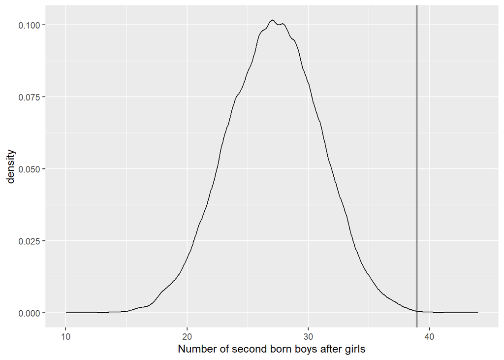

```r
# we draw from our simulation, draws of size of number of births after a girl (49)
sampled_births <- rbinom(1e4, size=length(births_after_girls), prob = samples)


tibble(male_births = sampled_births) %>%
  ggplot(aes(x = male_births)) +
  geom_density() + geom_vline(xintercept = sum(births_after_girls)) +
  labs(x = "Number of second born boys after girls")
```

Not a good fit. It seems that gender of birth is correlated between first and second born.